# Nonparametric Statistics Exam: January Session

Name, family name and ID number

2024-01-12

## Instructions

- For all computations based on permutation/bootstrapping, use $B = 1000$ replicates, and seed = $2024$ every time a permutation/bootstrap procedure is run.
- For Full Conformal prediction intervals, use a regular grid, where, for each dimension, you have $N = 20$ equispaced points with lower bound $min(data) - 0.25 · range(data)$ and upper bound $max(data) + 0.25 · range(data)$. Moreover, do not exclude the test point when calculating the conformity measure. Except for the number of points, these are the default conditions of the `ConformalInference` R package.
- Both for confidence and prediction intervals, as well as tests, if not specified otherwise, set $\alpha = 0.05$.
- When reporting univariate confidence/prediction intervals, always provide upper and lower bounds.
- For solving the exam, you must use one of the templates previously provided and available [here](https://polimi365-my.sharepoint.com/:f:/g/personal/10816355_polimi_it/Ev5Iy-DxrFtGtFh-4kyGwbsBLpIn37d2D1xdNIqjnU0Oow?e=zS8Qeo). Particularly, for each question you are required to report:
  - Synthetic description of assumptions, methods, and algorithms: which methodological procedure you intend to use to answer the question, succinctly describing the main theoretical characteristics of the chosen approach, and why it is suitable for the analytical task at hand. For e.g., if you perform a statistical test, you should mention its assumptions, null and alternative hypotheses, and the test statistic.
  - Results and brief discussion. the actual result of the procedure applied to the data at hand, including any requested comment, output and plot.

The files containing data are available [here](https://polimi365-my.sharepoint.com/:f:/g/personal/10794065_polimi_it/EspSDZeH6ZFJluO4dnEX2Y0B5i2P6JKVn1IiUUAZTFbwTA?e=gIR0LT)

## Exercise 1.

After reading [Doughnut Economics: Seven Ways To Think Like a 21st Century Economist](https://en.wikipedia.org/wiki/Doughnut_Economics:_Seven_Ways_to_Think_Like_a_21st-Century_Economist), Dr. LC Sulla is set out to test empirically whether the [Kuznets Curve and its environmental counterpart](https://en.wikipedia.org/wiki/Kuznets_curve) are verified in reality.

- Classical Kuznets curve: at first, growth increases with inequality and then wealth “lifts everyone up”, reducing inequality.

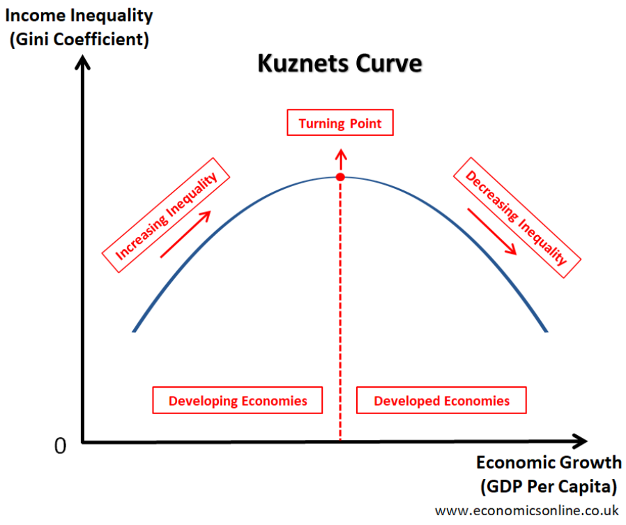

  [^1]
- Environmental Kuznets Curve (EKC): at first growth increases at the expense of environmental degradation. When people have sufficient income, the economy shifts to a less environment-degrading one. That is, after a turning point “economic growth cleans up”.

As a first step to the analysis, Dr. Sulla is performing an exploratory analysis on the gathered data ( *cf*. `df1.csv` ) for year $2010$ with the following variables collected from different countries: `IncomeGroup`, `GDP_per_capita`, `CO2_emissions`, `Gini_pct`, `Population`.

1. Retrieve the country codes with the three highest Tukey depths when taking into account the three dimensions`GDP_per_capita`, `CO2_emissions_per_capita` and the `logit` transformation of the `Gini` coefficient (which is essentially a measure of inequality defined in $(0,1)$ ).[^2]. Which one of them is the median?

```r
library(DepthProc)
df1 <- read.csv("df1.csv")

df1$Gini = sapply(df1$Gini, function(x)log(x/(1-x)))
depths <- depth(u=df1[,c(4,5,6)],method='Tukey')
df1[order(depths,decreasing = T)[1:6],]
```

[output not shown]

2. Focusing on those same dimensions, draw a bagplot matrix. Report the countries that are inside the bag of the `GDP_per_capita` versus `CO2_emissions` bagplot.[^3]. Report which countries are outliers of such bagplot and remove them from the data set for the following exercises.

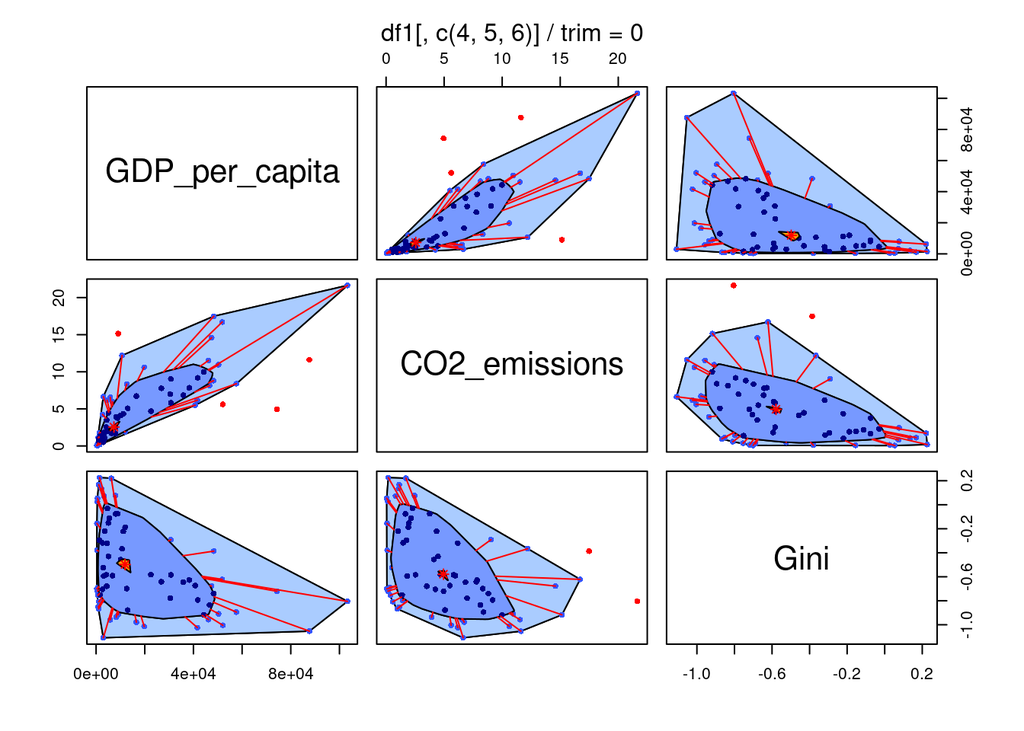

```r
library(aplpack)
bagpl.matri <- bagplot.pairs(df1[,c(4,5,6)])
```

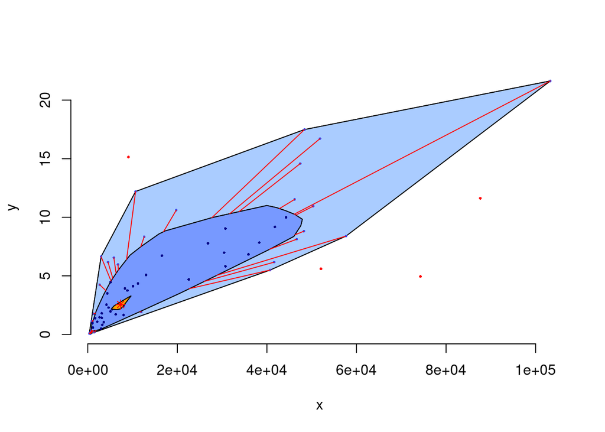

```r
bagplot_cont_normals <- bagplot(df1[,c(4,5)])
```

```r
depths.2 <- depth(u=df1[,c(4,5)],method='Tukey')
df1[order(depths.2, decreasing = T)[1:35],]


outlying_obs <- bagplot_cont_normals$pxy.outlier
outs.indices <-  which(apply(df1[,c(4,5)],1,function(x) all(x %in% outlying_obs)))
df1[outs.indices,]
```

[output not shown]

3. Without the aforementioned outliers in the dataset, implement through a permutational a MANOVA test for the equality of the multivariate mean (using `GDP_per_capita`, `CO2_emissions` and `logit(Gini)` ) of the three groups of countries according to `IncomeGroup`, utilising the Wilks statistic[^4]. Report the histogram of the Monte Carlo approximation of the permutational distribution of the test statistic, the resulting p-value of the test and your conclusion.

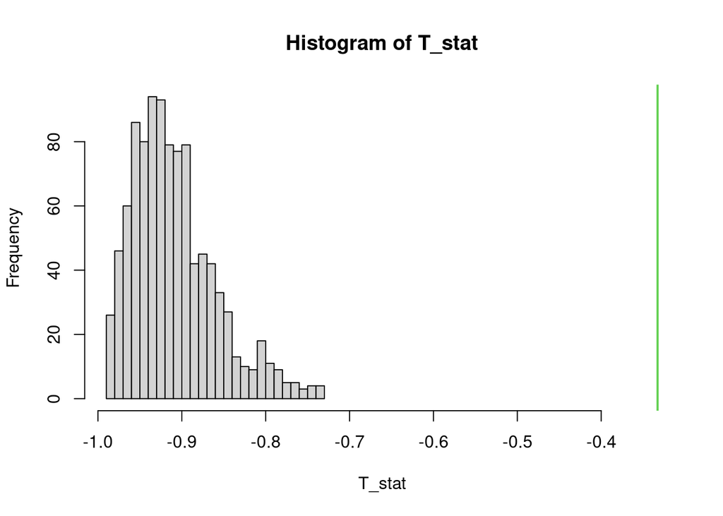

```r
df1 <- df1[-outs.indices, ]
B <- 1e3
seed = 2024

fit <- manova(as.matrix(df1[, c(4,5,6)]) ~ df1$IncomeGroup)
summary.manova(fit,test="Wilks")
T0 <- -summary.manova(fit,test="Wilks")$stats[1,2]

set.seed(seed)
T_stat <- numeric(B)
n <- dim(df1)[1]

for(perm in 1:B){
  # choose random permutation
  permutation <- sample(1:n)
  income.group.perm <- df1$IncomeGroup[permutation]
  fit.perm <- manova(as.matrix(df1[, c(4,5,6)]) ~ income.group.perm)
  T_stat[perm] <- -summary.manova(fit.perm,test="Wilks")$stats[1,2]
}
hist(T_stat,xlim=range(c(T_stat,T0)),breaks=30)
abline(v=T0,col=3,lwd=2)
```

[output not shown]

4.Perform a Mann-Whitney U test comparing to test the median `CO2_emissions` of *Middle income* countries and that of *High income countries*. Comment your result.

```r
wilcox.test(df1[df1$IncomeGroup=="High income",]$CO2_emissions,
            y=df1[df1$IncomeGroup=="Middle income",]$CO2_emissions, paired=F, conf.level = 1-.05)
```

[output not shown]

## Exercise 2

After some other touches to the data set (`df2.csv`), Dr. Sulla is ready to test for the existence of the Kuznets and the Environmental Kuznets curve.

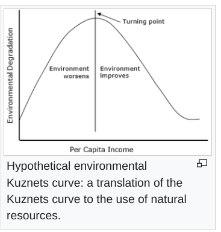

[^5]

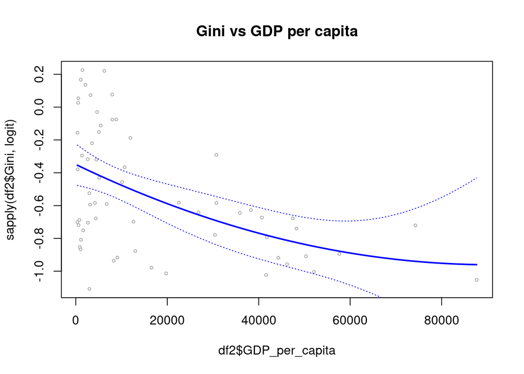

```r
logit <- function(x){log(x/(1-x))}
df2 <- read.csv("df2.csv")
names(df2)
m_quad=lm(I(sapply(Gini, logit)) ~ GDP_per_capita + I(GDP_per_capita^2), data=df2)
summary(m_quad)
gdp.grid <- seq(min(df2$GDP_per_capita), max(df2$GDP_per_capita), length.out=100)

preds=predict(m_quad,list(GDP_per_capita=gdp.grid),se=T)
se.bands=cbind(preds$fit +2* preds$se.fit ,preds$fit -2* preds$se.fit)

plot(df2$GDP_per_capita ,sapply(df2$Gini, logit) ,xlim=range(gdp.grid) ,cex =.5, col =" darkgrey ",main='Gini vs GDP per capita')
lines(gdp.grid, preds$fit ,lwd =2, col =" blue")
matlines (gdp.grid ,se.bands ,lwd =1, col =" blue",lty =3)
```

[output not shown]

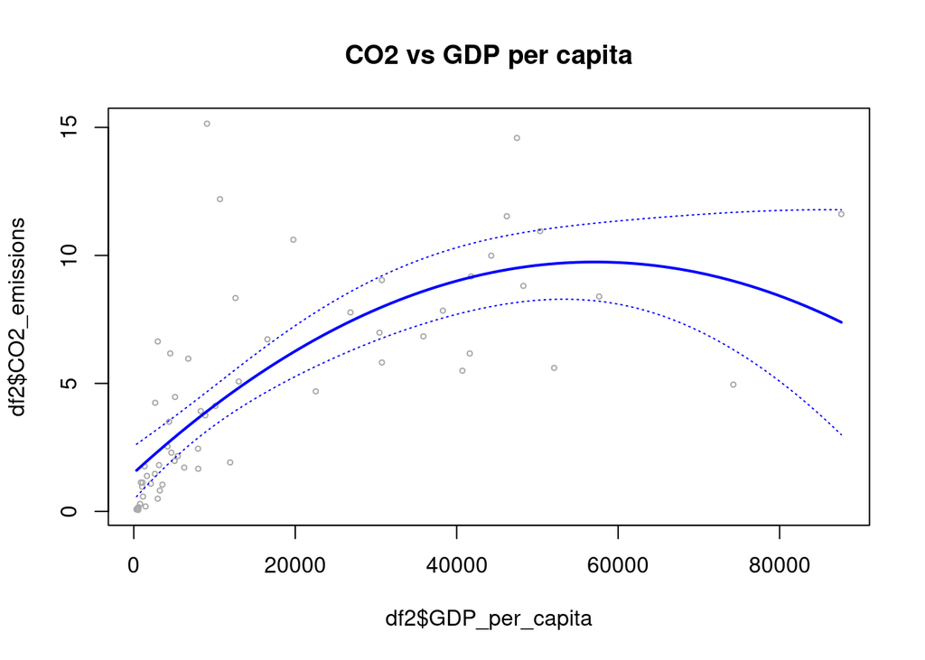

```r
m_quad=lm(CO2_emissions ~ GDP_per_capita + I(GDP_per_capita^2), data=df2)
summary(m_quad)
gdp.grid <- seq(min(df2$GDP_per_capita), max(df2$GDP_per_capita), length.out=100)

preds=predict(m_quad,list(GDP_per_capita=gdp.grid),se=T)
se.bands=cbind(preds$fit +2* preds$se.fit ,preds$fit -2* preds$se.fit)

plot(df2$GDP_per_capita ,df2$CO2_emissions,xlim=range(gdp.grid) ,cex =.5, col =" darkgrey ",main='CO2 vs GDP per capita')
lines(gdp.grid, preds$fit ,lwd =2, col =" blue")
matlines (gdp.grid ,se.bands ,lwd =1, col =" blue",lty =3)
```

[output not shown]

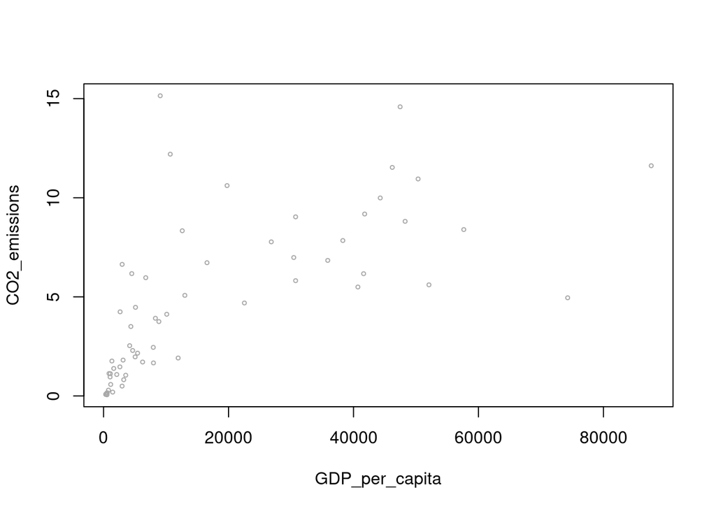

```r
grid = seq(range(df2$GDP_per_capita)[1],
                    range(df2$GDP_per_capita)[2],
                    length.out = 100)

with(
  df2,
  plot(
    GDP_per_capita ,
    CO2_emissions,
    xlim = range(grid) ,
    cex = .5,
    col = " darkgrey "
  )
)
```

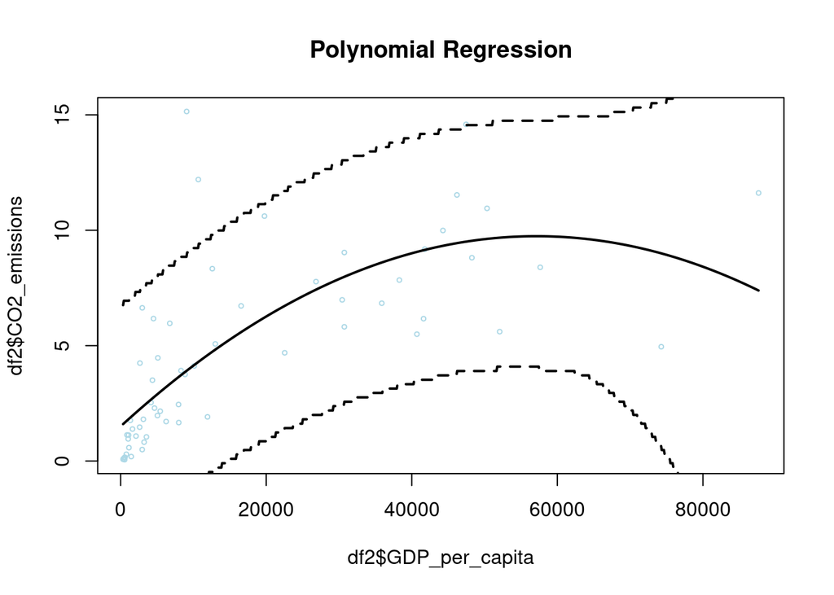

```r
library(conformalInference)
lm_train = lm.funs(intercept = T)$train.fun
lm_predict = lm.funs(intercept = T)$predict.fun

design_matrix = matrix(poly(df2$GDP_per_capita,degree=2,raw=T), ncol=2)
#design_matrix = matrix(cbind(df2$CO2_emissions, sapply(df2$CO2_emissions, function(x){x**2})))
gdp.grid <- seq(range(df2$GDP_per_capita)[1],range(df2$GDP_per_capita)[2],by=100)
pred_grid <- matrix(poly(gdp.grid,degree=2,raw=T,coefs=attr(poly(df2$GDP_per_capita,degree=2, raw=T),"coefs")),ncol=2)

c_preds <- conformal.pred(design_matrix, df2$CO2_emissions, pred_grid, alpha=0.05, verbose=F,
                          train.fun=lm_train, predict.fun=lm_predict, num.grid.pts = 200)

plot(df2$GDP_per_capita, df2$CO2_emissions, xlim=range(gdp.grid), cex =.5, col ="lightblue", main='Polynomial Regression')

lines(gdp.grid, c_preds$pred, lwd=2, col ="black", lty=1)
matlines(gdp.grid, cbind(c_preds$up,c_preds$lo), lwd=2, col="black",lty=2)
```

3. For the classical Kuznets curve, knowing that the Gini coefficient is a proportion, fit the following GAM :
   $$logit(Gini) = \sum_{g \in \mathcal{G}} \beta_{g} + \beta_1 f(GDP)$$
   where $\mathcal{G}$ = {Low income, Medium income, High income}, $f(GDP)$ is a quadratic B-spline with one knot on `GDP_per_capita`$=30000$. Provide a table summarising the coefficients of the regression, including a comment on statistical significance.

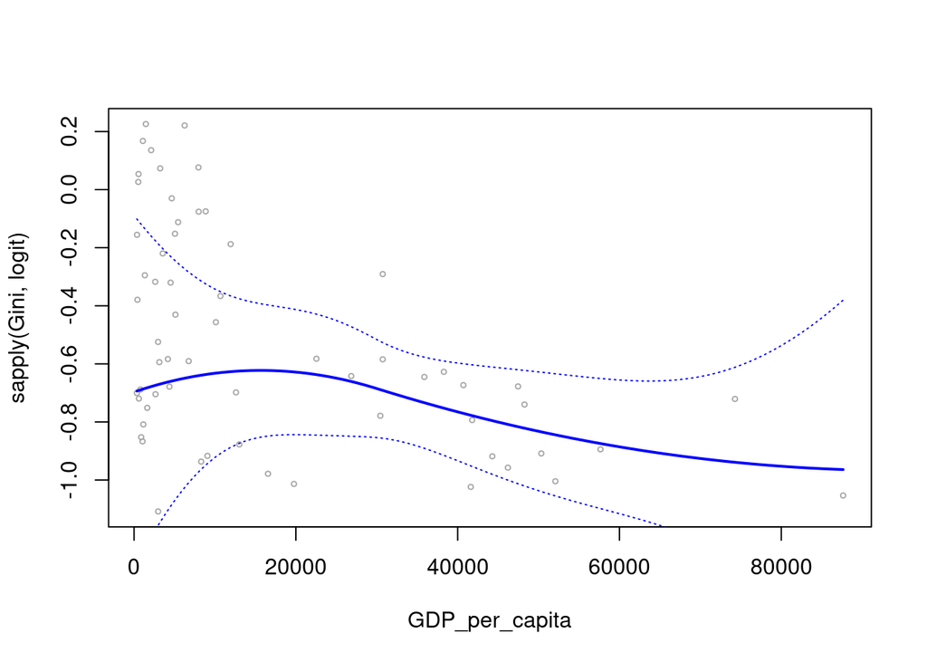

```r
library(splines)
m3 <- lm(I(sapply(Gini, logit)) ~ IncomeGroup + splines::bs(GDP_per_capita, degree=2, knots=c(30000)), data=df2)
new_data = data.frame(IncomeGroup=rep("High income",100), GDP_per_capita=seq(min(df2$GDP_per_capita), max(df2$GDP_per_capita), length.out=100))
preds=predict(m3,new_data,se=T)
se.bands=cbind(preds$fit +2* preds$se.fit ,preds$fit -2* preds$se.fit)

with(df2, plot(GDP_per_capita ,sapply(Gini, logit) ,xlim=range(new_data$GDP_per_capita) ,cex =.5, col =" darkgrey " ))
lines(new_data$GDP_per_capita ,preds$fit ,lwd =2, col =" blue")
matlines(new_data$GDP_per_capita, se.bands ,lwd =1, col =" blue",lty =3)
```

[output not shown]

4. With a Bootstrap approach, provide the a reverse percentile confidence interval for the prediction of the model at `GDP_per_capita`$=20000$ and `IncomeGroup`$=`High Income`

```r
res.estimate <- m3$residuals
fitted <- m3$fitted.values
T0 <- predict(m3, newdata=list(GDP_per_capita=20000, IncomeGroup="High income"))

T.boot <- numeric(B)
attach(df2)
set.seed(2024)

for (b in 1:B){
  boot <- sample(1:length(m3$residuals), replace=T)
  res.boot <- res.estimate[boot]
  m3boot <- lm(I(fitted+ res.boot)~ IncomeGroup + bs(GDP_per_capita, degree=2, knots=c(30000)))
  T.boot[b] <-  predict(m3boot, newdata=list(GDP_per_capita=20000, IncomeGroup="High income"))
}
detach(df2)
alpha <- 0.05
right.quantile <- quantile(T.boot, 1 - alpha/2)
left.quantile  <- quantile(T.boot, alpha/2)

CI.RP <- c(T0 - (right.quantile - T0), T0 - (left.quantile - T0))
CI.RP
```

[output not shown]

## Exercise 3

Before having a fallout with his (former) friend Dr. Marius, Dr. Sulla received from him a dataset of smoothed functions over time for the observations `GDP_per_capita`, `CO2_emissions` along time from $1990$ to $2010$.

1. By suitably defining a functional data object, plot the resulting curves for the $N = 57$ countries. Build a functional boxplot without adjusting the F value and report which countries are magnitude outliers.

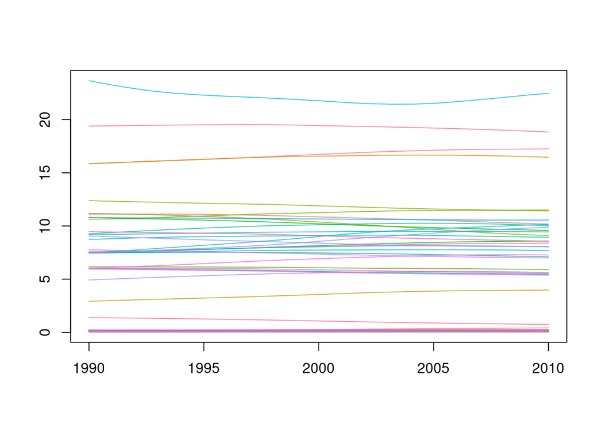

```r
library(roahd)
data3 <- readRDS("ex3.rds")
df.func<- data3$df3
time <- data3$time
f_data <- fData(time, df.func[, -c(1,2)])
plot(f_data) # what happens if I do plot(data)?
```

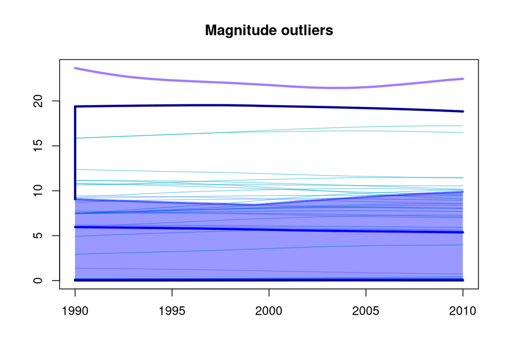

```r
fbp <- fbplot(f_data, main="Magnitude outliers",adjust = F)
```

```r
df.func[fbp$ID_outliers,c(1,2)]
```

[output not shown]

2. Provide the (point-wise) $\alpha=0.1$-trimmed mean of each group. [^6]. Add them the last plot. Calculate the pointwise p-value of a permutation test using as test statistic the difference of the pointwise $\alpha=0.1$-trimmed means of both groups and interpret your results. In this case, use $B=100$.

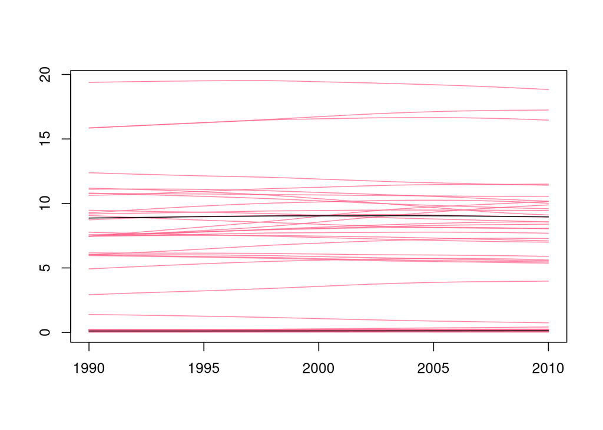

```r
plot(f_data[-fbp$ID_outliers])
mean.high <- apply(df.func[df.func$IncomeGroup=="High income", -c(1,2)], MARGIN=2, FUN=function(x){mean(x, trim=.1)})
lines(time, mean.high,col="black")
mean.low <- apply(df.func[df.func$IncomeGroup=="Low income", -c(1,2)], MARGIN=2, FUN=function(x){mean(x, trim=.1)})
lines(time, mean.low,col="black")
```

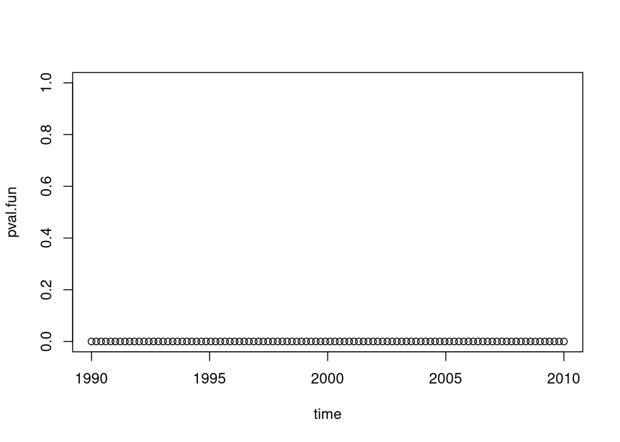

```r
uniperm=function(tindex,B=100){
  data <- df.func[, c(2,tindex+2)]
  n <- dim(data)[1]
  Tperm <- numeric(B)
  mean.high.pw <- mean(data[data$IncomeGroup=="High income", -1], trim=.1)
  mean.low.pw <- mean(data[data$IncomeGroup=="Low income", -1], trim=.1)
  t0 <- sqrt((mean.high.pw- mean.low.pw)**2)

  for(index in 1:B){
    perm <- sample(1:n, replace = F)
    dfperm <- data
    dfperm[, -1] <- data[perm, -1]
    mean.high.perm <- mean(dfperm[dfperm$IncomeGroup=="High income", -1], trim=.1)
    mean.low.perm <- mean(dfperm[dfperm$IncomeGroup=="Low income", -1], trim=.1)
  Tperm[index] <- sqrt((mean.high.perm - mean.low.perm)**2)
  }
  return(sum(Tperm>=t0)/B)
}

pval.fun=numeric(length(time))
for(index in 1:length(time)){
  set.seed(2024)
  pval.fun[index]=uniperm(index)
}

plot(time, pval.fun, ylim=c(0,1))
```

3. Following the logic of the EKC, high and low income countries should different `C02_emissions`. To see whether this is verified in the `C02_emissions` measured along time, perform a global permutation test for the equality of both functional $\alpha$-trimmed means, using as test statistic the $L2$ distance between the $\alpha$-trimmed means (built as in Exercise $1$) of both groups. You can approximate it with the euclidean distance of the discretely sampled ($100$ obs.) curves.

```r
euclidean <- function(a, b) sqrt(sum((a - b)^2))
T0 <- euclidean(mean.high, mean.low)
n <- dim(df.func)[1]
B <- 1000
Tperm <- numeric(B)
set.seed(2024)
for (b in 1:B){
  perm <- sample(1:n, replace = F)
  dfperm <- df.func
  dfperm[, -c(1,2)] <- df.func[perm, -c(1,2)]
  mean.high.perm <- apply(dfperm[dfperm$IncomeGroup=="High income", -c(1,2)], MARGIN=2, FUN=function(x){mean(x, trim=.1)})
  mean.low.perm <- apply(dfperm[dfperm$IncomeGroup=="Low income", -c(1,2)], MARGIN=2, FUN=function(x){mean(x, trim=.1)})
  Tperm[b] <- euclidean(mean.high.perm, mean.low.perm)
}
sum(Tperm>=T0)/B
```

[output not shown]

[^1]: Image taken from https://www.economicsonline.co.uk/definitions/the-kuznets-curve.html/
[^2]: Recall that $logit(x) = \ln \frac{x}{1-x}, x \in (0,1)$
[^3]: Hint: The deepest 50% of the data are contained in the bag. Note that the bagplot compares only two dimensions at a time.
[^4]: Remember that a smaller value of Wilks’s Lambda is associated to a higher significane in the test
[^5]: Image source: Wikipedia
[^6]: Hint: this reduces to the point-wise $\alpha$ -trimmed mean